# HN22

박찬영

2024-11-30

```r
library(haven)
library(tidyverse)
library(car)

data <- read_sav("F:\\data\\HN22_실습.sav")
```

데이터를 불러옵니다.

```r
pdata <- data %>%
  mutate(
    sex = factor(sex, labels = c("남자", "여자")),
    cursmoke = factor(cursmoke, labels = c("비흡연", "현재흡연")),
    BMI_group = cut(
      HE_BMI,
      breaks = c(-Inf, 20, 25, Inf),
      labels = c("저체중", "정상", "비만")
    ),
    BMI_group = fct_relevel(BMI_group, c("정상", "저체중", "비만"))
  )
glimpse(pdata)
```

```
## Rows: 500
## Columns: 33
## $ ID        <chr> "YH07274901", "YA09442801", "YC01645001", "YA41327501", "YH3…
## $ sex       <fct> 여자, 여자, 남자, 남자, 여자, 여자, 여자, 여자, 남자, 여자, …
## $ age       <dbl> 21, 50, 80, 65, 77, 49, 28, 68, 59, 47, 70, 36, 44, 63, 62, …
## $ HE_BMI    <dbl> 20.66503, 19.32665, NA, 24.60269, 21.79088, 20.63504, 20.528…
## $ smoke     <dbl> 3, 1, 2, 2, 3, 3, 3, 3, 2, 3, 3, 3, 3, 3, 3, 3, 3, 3, 3, 2, …
## $ cursmoke  <fct> 비흡연, 현재흡연, 비흡연, 비흡연, 비흡연, 비흡연, 비흡연, 비…
## $ edu       <dbl> 3, 3, 1, 3, 3, 3, 4, NA, 3, 4, 1, 4, 4, 1, 3, NA, 3, 4, 4, 2…
## $ marri_1   <dbl> 2, 1, 1, 1, 1, 1, 2, 1, 1, 1, 1, 1, 1, 1, 1, 1, 1, 2, 1, 2, …
## $ DI1_dg    <dbl> 0, 0, 0, 1, 1, 0, 0, 1, 0, 1, 1, 0, 0, 1, 0, 1, 0, 0, 0, 0, …
## $ DI1_ag    <dbl> 21, 50, 80, 53, 72, 49, 28, 58, 59, 42, 63, 36, 44, 42, 62, …
## $ DE1_dg    <dbl> 0, 0, 0, 0, 1, 0, 0, 0, 1, 0, 0, 0, 0, 0, 0, 0, 0, 0, 0, 0, …
## $ DE1_ag    <dbl> 21, 50, 80, 65, 72, 49, 28, 68, 55, 47, 70, 36, 44, 63, 62, …
## $ DI2_dg    <dbl> 0, 1, 1, 0, 1, 0, 0, 0, 1, 0, 1, 0, 0, 1, 0, 0, 1, 0, 1, 0, …
```

[output cut: 20 more lines]

```r
mod1 <- lm(HE_sbp ~ age + sex + HE_chol + HE_TG + BMI_group + cursmoke, data = pdata)
summary(mod1)
```

```
##
## Call:
## lm(formula = HE_sbp ~ age + sex + HE_chol + HE_TG + BMI_group +
##     cursmoke, data = pdata)
##
## Residuals:
##     Min      1Q  Median      3Q     Max
## -34.233  -8.554  -1.053   7.082  82.098
##
## Coefficients:
##                   Estimate Std. Error t value Pr(>|t|)
## (Intercept)      99.897961   4.008320  24.923  < 2e-16 ***
## age               0.337172   0.040117   8.405 5.38e-16 ***
## sex여자          -3.239898   1.374439  -2.357   0.0188 *
## HE_chol          -0.001017   0.015103  -0.067   0.9463
## HE_TG             0.014835   0.006876   2.157   0.0315 *
## BMI_group저체중  -5.569941   2.370856  -2.349   0.0192 *
## BMI_group비만     5.937871   1.419931   4.182 3.46e-05 ***
## cursmoke현재흡연  1.242854   1.784564   0.696   0.4865
## ---
## Signif. codes:  0 '***' 0.001 '**' 0.01 '*' 0.05 '.' 0.1 ' ' 1
##
## Residual standard error: 13.9 on 461 degrees of freedom
##   (31 observations deleted due to missingness)
## Multiple R-squared:  0.255,  Adjusted R-squared:  0.2437
## F-statistic: 22.55 on 7 and 461 DF,  p-value: < 2.2e-16
```

모형의 결정계수는 0.255이다. 이는 모델이 데이터의 25.5%를 설명한다고 할 수 있다.

age 변수의 기울기는 0.337이고 유의확률이 0.05보다 낮아 유의하다.  
이는 age 변수가 1 오를때 최종수축기혈압이 평균적으로 0.337 오른다는 의미이다.  
sex 변수의 기울기는 -3.240이고 유의확률이 0.05보다 낮아 유의하다.  
이는 sex 변수가 여자일 때 남자일때 보다 최종수축기혈압이 평균적으로 3.240 감소한다는 의미이다.  
HE_chol 변수의 기울기는 -0.001이고 유의확률은 0.9로 유의하지 않다.  
이는 HE_chol 변수가 1 오를때 최종수축기혈압이 평균적으로 0.001 감소한다는 의미이다.  
HE_TG 변수의 기울기는 0.0148이고 유의확률이 0.05보다 낮아 유의하다.  
이는 HE_TG 변수가 1 오를때 최종수축기혈압이 평균적으로 0.0148 오른다는 의미이다.  
BMI_group 변수는 저체중일 때 정상일 때보다 최종수축기혈압이 평균적으로 5.570 감소하고,  
비만일 때는 정상일 때보다 최종수축기혈압이 평균적으로 5.938 증가한다.  
각각의 더미 변수의 유의확률이 모두 0.05보다 낮아 유의하다.  
cursmoke 변수의 기울기는 1.243이고 유의확률은 0.487로 유의하지 않다.  
이는 cursmoke 변수가 현재흡연일 때 비흡연일 때보다 최종수축기혈압이 평균적으로 1.243 오른다는 의미이다.

age 변수의 기울기 계수 추정값은 0.337이다. age가 10만큼 오르면 최종수축기혈압은 평균적으로 10 * 0.337 = 3.37만큼 오른다.

```r
vif(mod1)
```

```
##               GVIF Df GVIF^(1/(2*Df))
## age       1.139520  1        1.067483
## sex       1.126416  1        1.061328
## HE_chol   1.105335  1        1.051349
## HE_TG     1.144940  1        1.070019
## BMI_group 1.180064  2        1.042261
## cursmoke  1.083494  1        1.040910
```

다중공선성을 확인하는 GVIF 테이블이다. 모든 변수에 대해서 값이 1.0정도로 작으므로 다중공선성이 없다고 판단 할 수 있다.

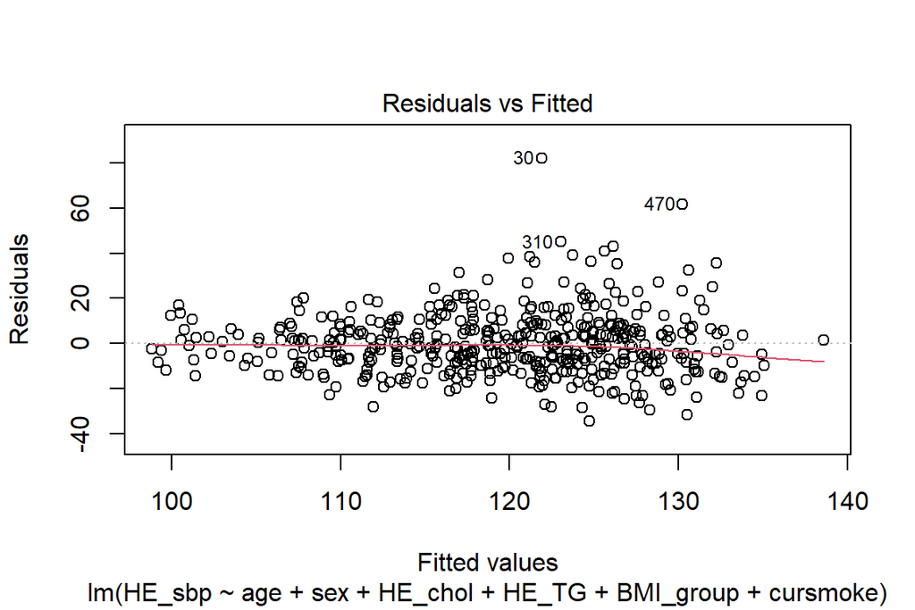

```r
plot(mod1, which = 1)
```

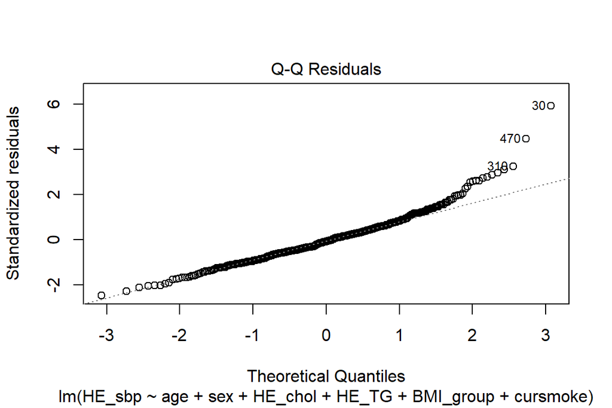

```r
plot(mod1, which = 2)
```

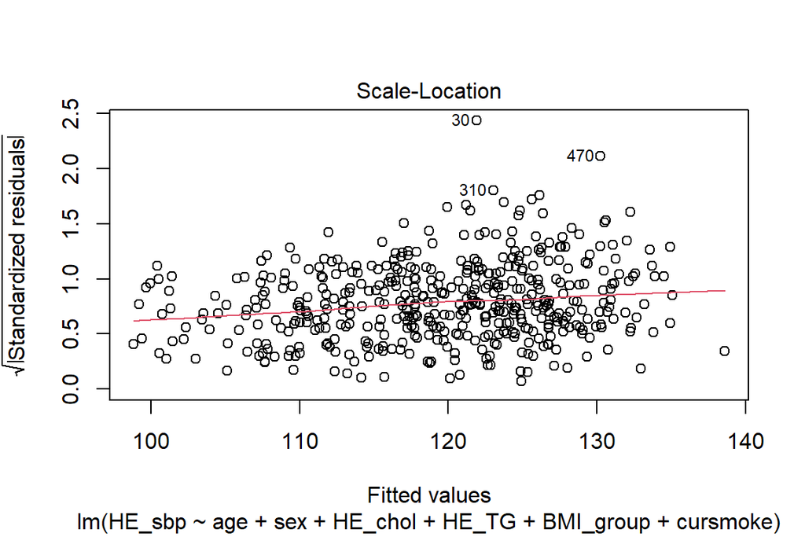

```r
plot(mod1, which = 3)
```

첫 번째 그래프는 residual plot으로 선형성을 확인한다. 잔차가 특별한 패턴을 띄지 않으므로 선형성을 만족한다고 볼 수 있다.

세 번째 그래프는 scale location plot이다. 이는 등분산성을 확인한다. 특별한 패턴을 띄지 않으므로 등분산성을 만족한다고 볼 수 있다.

```r
table <- pdata %>% select(BMI_group, mh_stress) %>% table()
table
```

```
##          mh_stress
## BMI_group   0   1
##    정상   213  63
##    저체중  28  19
##    비만   125  44
```

### 2.1

H0: BMI_group 은 스트레스 인지 분율과 독립적이다.  
H1: H0 is not true

분할표에대한 두 범주형 변수의 독립성 검정이므로 피어슨 카이제곱 검정을 시행한다.

```r
chisq.test(table)
```

```
##
##  Pearson's Chi-squared test
##
## data:  table
## X-squared = 6.554, df = 2, p-value = 0.03774
```

카이제곱 검정에 의하면 유의확률 0.038로 유의수준 0.05에서 귀무가설을 기각할 충분한 데이터이다.  
즉 두 변수 BMI_group과 mh_stress가 독립적이라는 가설을 기각할 수 있다.

BMI_group과 mh_stress 사이에 성별이라는 교란변수를 넣어서 Mantel-haenszel 검정을 실시한다.

```r
table2 <- pdata %>% select(BMI_group, mh_stress, sex) %>% table()
table2
```

```
## , , sex = 남자
##
##          mh_stress
## BMI_group   0   1
##    정상    97  20
##    저체중   4   1
##    비만    69  22
##
## , , sex = 여자
##
##          mh_stress
## BMI_group   0   1
##    정상   116  43
##    저체중  24  18
##    비만    56  22
```

### 2.2

H0: BMI_group과 스트레스 인지 분율은 성별에 관계없이 독립적이다.

H1: H0 is not true

성별을 기준으로 층화되었으므로, 성별에 따른 영향을 알아보기 위해 mantel_haenszel 검정을 실시한다.

```r
mantelhaen.test(table2)
```

```
##
##  Cochran-Mantel-Haenszel test
##
## data:  table2
## Cochran-Mantel-Haenszel M^2 = 4.6062, df = 2, p-value = 0.09995
```

검정결과 유의확률은 0.099로 유의수준 0.05보다 커서 귀무가설을 기각 할 수 없다. 즉 BMI_group과 스트레스 인지 분율의 관계는 성별에 관계없이 독립적이다는 가설을 기각 할 수 없다.

### 2.3

2.1에서의 방법은 교란변수인 성별을 고려하지 않은 방법이다. 성별을 고려하지 않으면 두 변수는 어떤 관계가 있다고 볼 수 있다.  
하지만 2.2에서 데이터를 성별에따라 층화시킨 후 검정을 실시하면 성별이 미치는 영향을 없앨 수 있다.  
성별이 두 변수의 관계에 미치는 영향을 배제하였을 때 두 변수는 독립적이라고 볼 수 있는데, 이는 성별이 두 변수사이에 교란변수로 작용했음을 알 수 있다.

단순한 카이제곱 검정에서는 교란변수를 고려하지 못하지만, mantel_haenszel 검정에서는 교란변수의 효과를 확인 할 수 있다.

```r
library(ResourceSelection)
```

```
## ResourceSelection 0.3-6   2023-06-27
```

```r
new_data <- pdata %>% mutate(SBP_group = HE_sbp > 120) %>%
  select(SBP_group, age, sex, HE_chol, HE_TG, BMI_group, cursmoke) %>% na.omit()

logistic_mod <- glm(SBP_group ~ ., family = binomial, data = new_data)
summary(logistic_mod)
```

```
##
## Call:
## glm(formula = SBP_group ~ ., family = binomial, data = new_data)
##
## Coefficients:
##                   Estimate Std. Error z value Pr(>|z|)
## (Intercept)      -3.220167   0.688326  -4.678 2.89e-06 ***
## age               0.045222   0.007015   6.447 1.14e-10 ***
## sex여자          -0.414337   0.216751  -1.912  0.05593 .
## HE_chol           0.000576   0.002361   0.244  0.80726
## HE_TG             0.003199   0.001341   2.386  0.01704 *
## BMI_group저체중  -0.683140   0.490754  -1.392  0.16392
## BMI_group비만     0.600031   0.224243   2.676  0.00746 **
## cursmoke현재흡연  0.054318   0.288557   0.188  0.85069
## ---
## Signif. codes:  0 '***' 0.001 '**' 0.01 '*' 0.05 '.' 0.1 ' ' 1
##
## (Dispersion parameter for binomial family taken to be 1)
##
##     Null deviance: 641.68  on 468  degrees of freedom
## Residual deviance: 546.48  on 461  degrees of freedom
## AIC: 562.48
##
## Number of Fisher Scoring iterations: 4
```

```r
hoslem.test(new_data$SBP_group, fitted(logistic_mod), g = 10)
```

```
##
##  Hosmer and Lemeshow goodness of fit (GOF) test
##
## data:  new_data$SBP_group, fitted(logistic_mod)
## X-squared = 7.8292, df = 8, p-value = 0.4503
```

### 3.1

H0: 모델이 데이터에 잘 맞는다.  
H1: 모델이 데이터에 잘 맞지 않는다.  
가설 검정을 진행한다.  
로지스틱 회귀모델이므로 Hosmer-Lemeshow 검정을 진행하였다.  
그 결과 p-value는 0.450으로 귀무가설을 기각할 만 한 충분한 증거를 제공하지 못한다.  
즉 모델이 데이터에 잘 맞는다는 가설을 기각 할 수 없다.

### 3.2

age 변수의 기울기는 0.045이고 유의확률이 0.05보다 낮아 유의하다.  
이는 age 변수가 1 오를때 SBP_group의 로그 오즈값이 이 평균적으로 0.045 오른다는 의미이다.  
sex 변수의 기울기는 -0.414이고 유의확률이 0.0559로 유의하지 않다.  
이는 sex 변수가 여자일 때 남자일때 보다 SBP_group의 로그 오즈값이 평균적으로 0.414 감소한다는 의미이다.  
HE_chol 변수의 기울기는 0.0005이고 유의확률은 0.807로 유의하지 않다.  
이는 HE_chol 변수가 1 오를때 SBP_group의 로그 오즈값이 평균적으로 0.0005 증가한다는 의미이다.  
HE_TG 변수의 기울기는 0.003이고 유의확률이 0.05보다 낮아 유의하다.  
이는 HE_TG 변수가 1 오를때 SBP_group의 로그 오즈값이 평균적으로 0.003 오른다는 의미이다.  
BMI_group 변수는 저체중일 때 정상일 때보다 SBP_group의 로그 오즈값이 평균적으로 0.683 감소하고,  
비만일 때는 정상일 때보다 SBP_group의 로그 오즈값이 평균적으로 0.600 증가한다.  
저체중일 때의 회귀계수 기울기의 유의확률은 0.164로 유의하지않고,  
비만일때의 회귀계수 기울기의 유의확률은 0.05보다 낮아 유의하다.  
cursmoke 변수의 기울기는 0.054이고 유의확률은 0.850로 유의하지 않다.  
이는 cursmoke 변수가 현재흡연일 때 비흡연일 때보다 SBP_group의 로그 오즈값이 평균적으로 0.054 오른다는 의미이다.

### 3.3

```r
library(caret)
pred_prob <- predict(logistic_mod, type = "response") >= 0.4
real_prob <- new_data$SBP_group
table(pred_prob, real_prob)
```

```
##          real_prob
## pred_prob FALSE TRUE
##     FALSE   160   47
##     TRUE    106  156
```

TRUE는 위험군, FALSE는 정상군이다.  
민감도는 156 / (47 + 156) = 0.768이다.  
특이도는 160 / (160 + 106) = 0.601이다.

### 3.4

```r
library(yardstick)
```

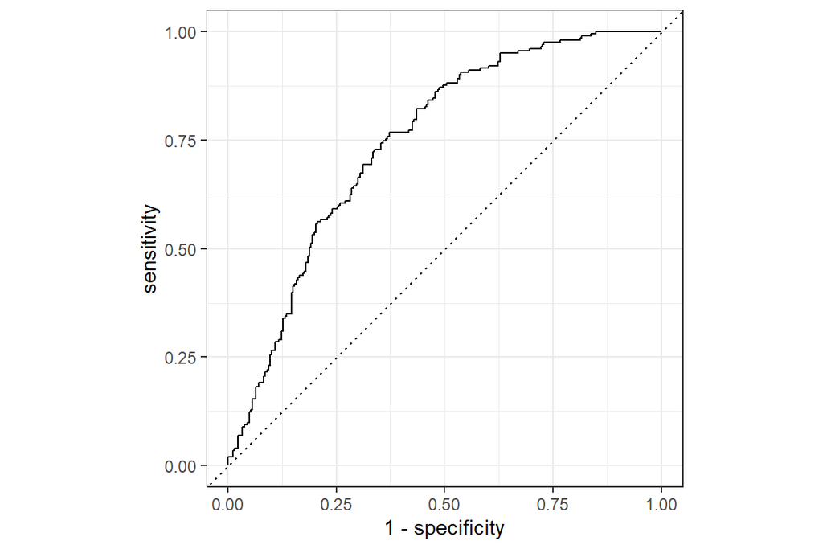

```r
ddata <- data.frame(truth = factor(real_prob, levels = c("TRUE", "FALSE")), prob = predict(logistic_mod, type = "response"))
roc <- roc_curve(ddata, truth, prob)

autoplot(roc)
```

```r
roc_auc(ddata, truth, prob)
```

```
## # A tibble: 1 × 3
##   .metric .estimator .estimate
##   <chr>   <chr>          <dbl>
## 1 roc_auc binary         0.747
```

AUC값은 0.747이다.  
양성과 음성 샘플을 무작위로 선택했을 때, 양성 샘플이 더 높은 예측값을 가질 확률이 0.747이라는 의미이다.